# 04 Totales y Proporciones

FES Acatlán

septiembre de 2021

# Estimadores, Intervalos de Confianza y Tamaños de Muestra para Totales y Proporciones.

## Totales

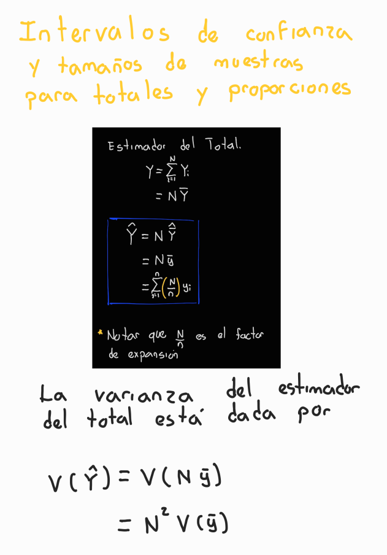

notas

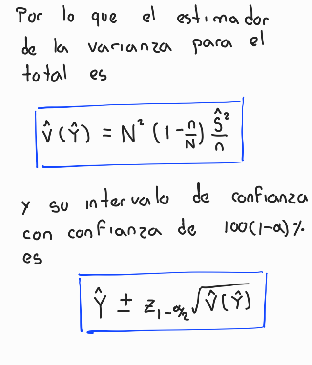

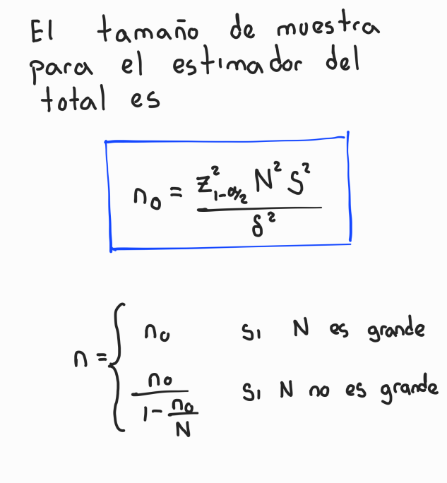

Usaremos datos del Censo 2010. [Censo 2010](https://www.inegi.org.mx/programas/ccpv/2010/#Microdatos).

**Descripción de los datos**

Para el levantamiento de la muestra censal 2010 se diseñó un cuestionario ampliado, con el que fueron censadas alrededor de 2.9 millones de viviendas en el país, seleccionadas con criterios probabilísticos.

Consta de 2 cuestionarios: básico y ampliado.

**Objetivos**. Por medio de la muestra censal se estiman tasas, promedios y proporciones.

**Diseño**. El diseño de la muestra censal 2010 es estratificado por conglomerados y se realizó en una sola etapa de selección, es decir, se seleccionan áreas geográficas completas, ya sean manzanas o localidades. Dentro de estas áreas se aplica el cuestionario ampliado a todas las viviendas particulares habitadas

```r
# Limpiar área de trabajo
rm(list = ls())
```

```r
# Cargar librerías
suppressMessages(library(tidyverse))
library(ggplot2)
library(readr)
library(stringr)

library(haven)
```

Leer datos de viviendas

```r
viviendas_15a <- read_sas("~/Documentos/Acatlan/datos/Censo_2010/MC2010_15_sas/viviendas_15a.sas7bdat", NULL)
glimpse(viviendas_15a)
```

```
## Rows: 220,655
## Columns: 56
## $ ENT       <chr> "15", "15", "15", "15", "15", "15", "15", "15", "15", …
## $ NOM_ENT   <chr> "México", "México", "México", "México", "México", "Méx…
## $ MUN       <chr> "001", "001", "001", "001", "001", "001", "001", "001"…
## $ NOM_MUN   <chr> "Acambay", "Acambay", "Acambay", "Acambay", "Acambay",…
## $ LOC50K    <chr> "0000", "0000", "0000", "0000", "0000", "0000", "0000"…
## $ NOM_LOC   <chr> "Localidad de menos de 50 mil habitantes", "Localidad …
## $ ID_VIV    <chr> "00000253", "00000279", "00000906", "00001481", "00001…
## $ CLAVIVP   <chr> "1", "1", "1", "1", "1", "1", "1", "1", "1", "1", "1",…
## $ PAREDES   <chr> "8", "7", "8", "8", "8", "8", "8", "7", "8", "8", "8",…
## $ TECHOS    <chr> "09", "09", "09", "09", "09", "09", "09", "08", "09", …
## $ PISOS     <chr> "2", "2", "2", "2", "3", "2", "3", "2", "2", "2", "2",…
## $ COCINA    <chr> "1", "1", "1", "1", "1", "1", "1", "1", "3", "1", "3",…
## $ CUADORM   <chr> "02", "03", "01", "02", "01", "02", "04", "02", "03", …
```

[output cut: 43 more lines]

¿Cuántos municipios hay en el Estado de México?

```r
viviendas_15a %>% summarise(num_mun = n_distinct(MUN))
```

```
## # A tibble: 1 x 1
##   num_mun
##     <int>
## 1     125
```

Si nuestros datos tuvieran información de más de 1 estado, ¿podríamos hacer ejecutar la línea de código anterior para saber el número de municipios?

```r
viviendas_15a %>% mutate(LLAVE = paste(ENT,MUN,sep = "_")) %>% summarise(num_mun = n_distinct(LLAVE))
```

```
## # A tibble: 1 x 1
##   num_mun
##     <int>
## 1     125
```

Número de viviendas en la muestra

```r
viviendas_15a %>% summarise( registros = n())
```

```
## # A tibble: 1 x 1
##   registros
##       <int>
## 1    220655
```

Número de registros de viviendas por municipio

```r
# ¿Por qué incluir la variable ENT en el group by?. Es una buena práctica para no perder el identificador
viviendas_15a %>% group_by(ENT, NOM_ENT, MUN, NOM_MUN) %>%  summarise( registros = n())
```

```
## # A tibble: 125 x 5
## # Groups:   ENT, NOM_ENT, MUN [125]
##    ENT   NOM_ENT MUN   NOM_MUN                registros
##    <chr> <chr>   <chr> <chr>                      <int>
##  1 15    México  001   Acambay                     1388
##  2 15    México  002   Acolman                     1753
##  3 15    México  003   Aculco                       957
##  4 15    México  004   Almoloya de Alquisiras       889
##  5 15    México  005   Almoloya de Juárez           866
##  6 15    México  006   Almoloya del Río             912
##  7 15    México  007   Amanalco                    1262
##  8 15    México  008   Amatepec                    1177
##  9 15    México  009   Amecameca                   1012
## 10 15    México  010   Apaxco                      1594
## # … with 115 more rows
```

**Estimación del total de Viviendas en el Estado de México**

¿Cómo estimamos el total de viviendas a partir de la muestra que nos proporcionaron? Hasta ahora no conocemos el tamaño de la población $N$.

```r
viviendas_15a %>% summarise(num_viviendas = sum(FACTOR))
```

```
## # A tibble: 1 x 1
##   num_viviendas
##           <dbl>
## 1       3723607
```

La información contiene la variable de número de personas por Viviendas. Con cifras del Censo de 2010, ¿cuántas personas vivían en el Estado de México?.

```r
viviendas_15a %>% mutate(num_personas = parse_number(NUMPERS)) %>%
  summarise( num_personas = sum(FACTOR*num_personas))
```

```
## # A tibble: 1 x 1
##   num_personas
##          <dbl>
## 1     15123304
```

Estimación del número de viviendas y personas por municipio

```r
tabla_viviendas <- viviendas_15a %>%
  mutate(num_personas = parse_number(NUMPERS)) %>%
  group_by(ENT, NOM_ENT, MUN, NOM_MUN) %>%
  summarise( num_viviendas = sum(FACTOR), num_personas = sum(FACTOR*num_personas)) %>%
  ungroup()
tabla_viviendas
```

```
## # A tibble: 125 x 6
##    ENT   NOM_ENT MUN   NOM_MUN                num_viviendas num_personas
##    <chr> <chr>   <chr> <chr>                          <dbl>        <dbl>
##  1 15    México  001   Acambay                        13676        60072
##  2 15    México  002   Acolman                        33032       132963
##  3 15    México  003   Aculco                         10118        44045
##  4 15    México  004   Almoloya de Alquisiras          3400        14344
##  5 15    México  005   Almoloya de Juárez             33547       144319
##  6 15    México  006   Almoloya del Río                2581        11624
##  7 15    México  007   Amanalco                        4983        21614
##  8 15    México  008   Amatepec                        6108        24709
##  9 15    México  009   Amecameca                      11974        49811
## 10 15    México  010   Apaxco                          6127        25884
## # … with 115 more rows
```

Revisar algún minucipio de interés. Municiío donde está la FES Acatlán.

```r
tabla_viviendas %>% filter(MUN %in% c("013","057"))
```

```
## # A tibble: 2 x 6
##   ENT   NOM_ENT MUN   NOM_MUN              num_viviendas num_personas
##   <chr> <chr>   <chr> <chr>                        <dbl>        <dbl>
## 1 15    México  013   Atizapán de Zaragoza        128483       489879
## 2 15    México  057   Naucalpan de Juárez         219288       829816
```

**Presentar estimaciones de forma gráfica**

Utilizaremos los datos de vivienda de la **cdmx**

```r
viviendas_09a <- read_sas("~/Documentos/Acatlan/datos/Censo_2010/MC2010_09_sas/viviendas_09.sas7bdat", NULL)
glimpse(viviendas_09a)
```

```
## Rows: 97,838
## Columns: 56
## $ ENT       <chr> "09", "09", "09", "09", "09", "09", "09", "09", "09", …
## $ NOM_ENT   <chr> "Distrito Federal", "Distrito Federal", "Distrito Fede…
## $ MUN       <chr> "002", "002", "002", "002", "002", "002", "002", "002"…
## $ NOM_MUN   <chr> "Azcapotzalco", "Azcapotzalco", "Azcapotzalco", "Azcap…
## $ LOC50K    <chr> "0001", "0001", "0001", "0001", "0001", "0001", "0001"…
## $ NOM_LOC   <chr> "Azcapotzalco", "Azcapotzalco", "Azcapotzalco", "Azcap…
## $ ID_VIV    <chr> "00922199", "00922204", "00922206", "00922207", "00922…
## $ CLAVIVP   <chr> "2", "2", "2", "2", "2", "2", "2", "2", "2", "2", "2",…
## $ PAREDES   <chr> "8", "8", "8", "8", "8", "8", "8", "8", "8", "8", "8",…
## $ TECHOS    <chr> "09", "09", "09", "09", "09", "09", "09", "09", "09", …
## $ PISOS     <chr> "3", "3", "3", "3", "3", "3", "3", "2", "3", "3", "3",…
## $ COCINA    <chr> "1", "1", "1", "1", "3", "1", "1", "1", "1", "1", "1",…
## $ CUADORM   <chr> "03", "03", "03", "03", "01", "03", "03", "03", "02", …
```

[output cut: 43 more lines]

Estimación de Viviendas y Personas

```r
viviendas_09a %>%
  mutate(num_personas = parse_number(NUMPERS)) %>%
           summarise(num_viviendas = sum(FACTOR), num_personas = sum(FACTOR*num_personas))
```

```
## # A tibble: 1 x 2
##   num_viviendas num_personas
##           <dbl>        <dbl>
## 1       2450563      8783909
```

¿Por qué no es la misma estimación reportada en la página del INEGI?

Veamos los tipos de Vivienda. revisar los distintos tipos de categoría. Consultar catálogo para saber el descriptivo de las categorías

```r
viviendas_09a %>% group_by(CLAVIVP) %>% summarise(conteo = n(), factor = sum(FACTOR))
```

```
## # A tibble: 8 x 3
##   CLAVIVP conteo  factor
##   <chr>    <int>   <dbl>
## 1 1        59878 1540951
## 2 2        31650  768756
## 3 3         5049  105378
## 4 4          400    8739
## 5 5           68    9471
## 6 6           12     247
## 7 7            9     204
## 8 9          772   16817
```

Estimación de Viviendas y Personas (considerando las reglas de negocio)

```r
viviendas_09a %>%
  filter(CLAVIVP %in% c("1","2","3","4","9")) %>%
  mutate(num_personas = parse_number(NUMPERS)) %>%
           summarise(num_viviendas = sum(FACTOR), num_personas = sum(FACTOR*num_personas))
```

```
## # A tibble: 1 x 2
##   num_viviendas num_personas
##           <dbl>        <dbl>
## 1       2440641      8770578
```

```r
viviendas_x_municipio <- viviendas_09a %>%
  filter(CLAVIVP %in% c("1","2","3","4","9")) %>%
  mutate(num_personas = parse_number(NUMPERS), unos = 1) %>%
  group_by(ENT, NOM_ENT, MUN, NOM_MUN) %>%
  summarise( registros = n(), num_viviendas = sum(FACTOR), num_personas = sum(FACTOR*num_personas)) %>%
  ungroup()
viviendas_x_municipio
```

```
## # A tibble: 16 x 7
##    ENT   NOM_ENT    MUN   NOM_MUN      registros num_viviendas num_personas
##    <chr> <chr>      <chr> <chr>            <int>         <dbl>        <dbl>
##  1 09    Distrito … 002   Azcapotzalco      3410        119223       414069
##  2 09    Distrito … 003   Coyoacán          5681        182140       619066
##  3 09    Distrito … 004   Cuajimalpa …      3090         47660       186253
##  4 09    Distrito … 005   Gustavo A. …     10673        320445      1170706
##  5 09    Distrito … 006   Iztacalco         4045        101505       383255
##  6 09    Distrito … 007   Iztapalapa       15456        460221      1793115
##  7 09    Distrito … 008   La Magdalen…      2040         62897       238352
##  8 09    Distrito … 009   Milpa Alta        1279         30810       129384
##  9 09    Distrito … 010   Álvaro Obre…      7586        195716       725077
## 10 09    Distrito … 011   Tláhuac           3810         89507       359045
## 11 09    Distrito … 012   Tlalpan           8119        177562       644855
## 12 09    Distrito … 013   Xochimilco        5769        101665       407369
## 13 09    Distrito … 014   Benito Juár…      5581        139399       382795
## 14 09    Distrito … 015   Cuauhtémoc       10088        174004       522805
## 15 09    Distrito … 016   Miguel Hida…      5367        120400       371460
## 16 09    Distrito … 017   Venustiano …      5755        117487       422972
```

Grafica de barras

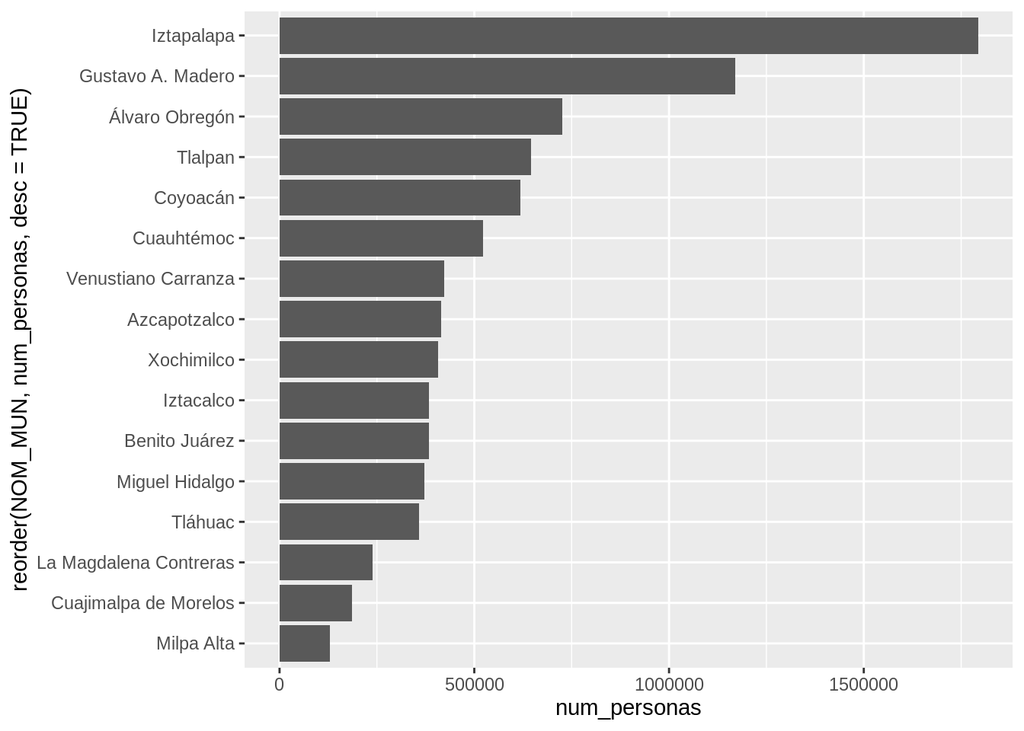

```r
ggplot(data = viviendas_x_municipio) +
geom_col(mapping = aes(x = reorder(NOM_MUN,num_personas, desc = TRUE), y = num_personas)) +
coord_flip()
```

Misma gráfica para ver el impacto de los factores de expansión

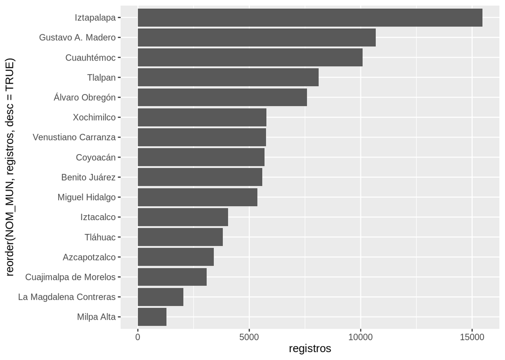

```r
ggplot(data = viviendas_x_municipio) +
geom_col(mapping = aes(x = reorder(NOM_MUN,registros, desc = TRUE), y = registros)) +
coord_flip()
```

Uno de los recursos que pone el INEGI a la disposición de los usuarios son archivos con coordenadas de polígonos. Estos archivos permiten graficar mapas. Iniciaremos con municipios, se puede ver mayor nivel de desglose, entre ellos los llamados AGEB (área geoestadística básica).

```r
#Cargar librería para graficar mapas
library(sf)
# Leer el dataframe de shapes
shapes <- st_read("~/Documentos/Acatlan/datos/shapes/01_32_mun.shp")
glimpse(shapes)
```

```
## Rows: 2,463
## Columns: 5
## $ CVEGEO   <fct> 01001, 01002, 01003, 01004, 01005, 01006, 01007, 01008,…
## $ CVE_ENT  <fct> 01, 01, 01, 01, 01, 01, 01, 01, 01, 01, 01, 02, 02, 02,…
## $ CVE_MUN  <fct> 001, 002, 003, 004, 005, 006, 007, 008, 009, 010, 011, …
## $ NOMGEO   <fct> Aguascalientes, Asientos, Calvillo, Cosío, Jesús María,…
## $ geometry <MULTIPOLYGON [m]> MULTIPOLYGON (((2489073 111..., MULTIPOLYG…
```

Unir la info con los shapefiles. Es importante tener colapsada la información a nivel estado municipio para no duplicar información.

```r
viviendas_shapes <- shapes %>%
                    left_join((viviendas_x_municipio %>% mutate(llave = paste(ENT,MUN,sep = ""))), by = c("CVEGEO"="llave"))

glimpse(viviendas_shapes)
```

```
## Rows: 2,463
## Columns: 12
## $ CVEGEO        <chr> "01001", "01002", "01003", "01004", "01005", "0100…
## $ CVE_ENT       <fct> 01, 01, 01, 01, 01, 01, 01, 01, 01, 01, 01, 02, 02…
## $ CVE_MUN       <fct> 001, 002, 003, 004, 005, 006, 007, 008, 009, 010, …
## $ NOMGEO        <fct> Aguascalientes, Asientos, Calvillo, Cosío, Jesús M…
## $ ENT           <chr> NA, NA, NA, NA, NA, NA, NA, NA, NA, NA, NA, NA, NA…
## $ NOM_ENT       <chr> NA, NA, NA, NA, NA, NA, NA, NA, NA, NA, NA, NA, NA…
## $ MUN           <chr> NA, NA, NA, NA, NA, NA, NA, NA, NA, NA, NA, NA, NA…
## $ NOM_MUN       <chr> NA, NA, NA, NA, NA, NA, NA, NA, NA, NA, NA, NA, NA…
## $ registros     <int> NA, NA, NA, NA, NA, NA, NA, NA, NA, NA, NA, NA, NA…
## $ num_viviendas <dbl> NA, NA, NA, NA, NA, NA, NA, NA, NA, NA, NA, NA, NA…
## $ num_personas  <dbl> NA, NA, NA, NA, NA, NA, NA, NA, NA, NA, NA, NA, NA…
## $ geometry      <MULTIPOLYGON [m]> MULTIPOLYGON (((2489073 111..., MULTI…
```

**Ejercicio**. Revisar el porcentaje de registros que hacen match. ¿Por qué esto es importante?

**Pregunta**. ¿Qué pasa si hubieramos hecho la union de tablas utilizando como tabla izquierda la tabla de viviendas por municipio?

```r
datos_grafica <- viviendas_shapes  %>%
                filter(CVE_ENT == '09') %>%
                mutate(nombre_etiqueta = ifelse(num_personas < 500000,NOM_MUN,""))
```

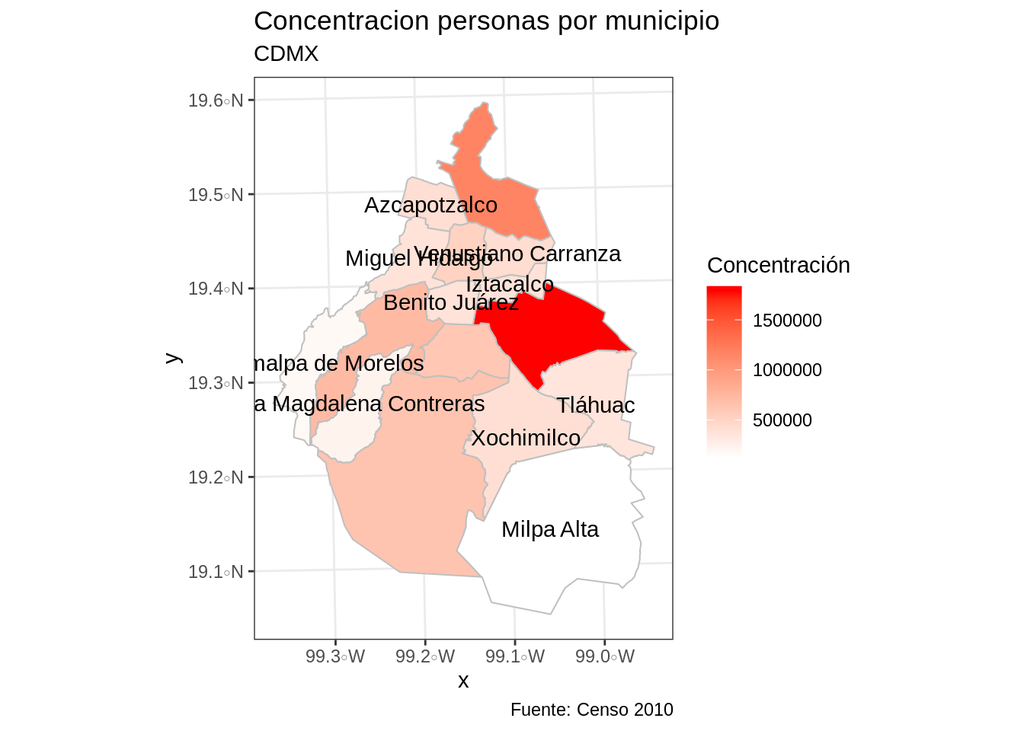

```r
datos_grafica %>%
  ggplot(aes(fill = num_personas)) +
  geom_sf(colour = "grey75", size = 0.35) +
  labs(title = "Concentracion personas por municipio",
       subtitle = "CDMX",
       caption = "Fuente: Censo 2010") +
  scale_fill_gradient("Concentración", high = "red", low = "white") +
  theme_bw() +
  geom_sf_text(aes(label = nombre_etiqueta))
```

**Ejercicio**. Replicar para Edo Mex y pintar la etiqueta solamente para los top 3 estados con mayor número de personas

### Intervalos de Confianza (Totales)

Construiremos un Intervalo de Confianza para el Total de Viviendas de la CMDX bajo Muestreo Aleatorio Simple.

¿Qué pasos debemos seguir?, ¿Qué valores debemos calcular?

```r
viviendas_09a %>%
  filter(CLAVIVP %in% c("1","2","3","4","9")) %>%
  mutate(num_personas = parse_number(NUMPERS)) %>%
  summarise(n = n(),
    num_viviendas = sum(FACTOR), var_viv = var(FACTOR), promedio = mean(FACTOR))
```

```
## # A tibble: 1 x 4
##       n num_viviendas var_viv promedio
##   <int>         <dbl>   <dbl>    <dbl>
## 1 97749       2440641   1837.     25.0
```

Asignar valores a variables (Notar que esto se puede automatizar)

```r
N <- 2440641
n <- 97749
var <- 1837.469
```

La varianza estimada está dada por

```r
var_est <- (n**2) * (var/n) * (1 - n/N)
## ee: error estándar
ee <- sqrt(var_est)
ee
```

```
## [1] 13130.77
```

**importante**. Reflexionar por qué la $n$ al cuadrado es sobre la muestra en la formula para estimar la varianza y no sobre $N$.

Definir la confianza

```r
alpha <- 0.10
z <- qnorm(1-alpha/2)
z
```

```
## [1] 1.644854
```

Los límites del intervalo son

```r
limite_inferior <- 2440641 - z*ee
limite_superior <- 2440641 + z*ee
c(limite_inferior,limite_superior)
```

```
## [1] 2419043 2462239
```

Veremos otro ejemplo usando las **tablas de Personas**

```r
personas_09a <- read_sas("~/Documentos/Acatlan/datos/Censo_2010/MC2010_09_sas/personas_09.sas7bdat", NULL)
glimpse(personas_09a)
```

```
## Rows: 353,030
## Columns: 95
## $ ENT        <chr> "09", "09", "09", "09", "09", "09", "09", "09", "09",…
## $ NOM_ENT    <chr> "Distrito Federal", "Distrito Federal", "Distrito Fed…
## $ MUN        <chr> "002", "002", "002", "002", "002", "002", "002", "002…
## $ NOM_MUN    <chr> "Azcapotzalco", "Azcapotzalco", "Azcapotzalco", "Azca…
## $ LOC50K     <chr> "0001", "0001", "0001", "0001", "0001", "0001", "0001…
## $ NOM_LOC    <chr> "Azcapotzalco", "Azcapotzalco", "Azcapotzalco", "Azca…
## $ ID_VIV     <chr> "00922199", "00922199", "00922199", "00922199", "0092…
## $ ID_PER     <chr> "003785161", "003785166", "003785169", "003785173", "…
## $ CLAVIVP    <chr> "2", "2", "2", "2", "2", "2", "2", "2", "2", "2", "2"…
## $ NUMPER     <chr> "00001", "00002", "00003", "00004", "00005", "00006",…
## $ SEXO       <chr> "1", "3", "3", "1", "3", "3", "3", "3", "3", "1", "1"…
## $ EDAD       <chr> "060", "056", "038", "030", "023", "007", "049", "080…
## $ PARENT     <chr> "01", "02", "03", "03", "03", "04", "01", "06", "08",…
```

[output cut: 82 more lines]

Estimación del número de Personas

```r
personas_09a %>% summarise(n = n(), num_personas = sum(FACTOR))
```

```
## # A tibble: 1 x 2
##        n num_personas
##    <int>        <dbl>
## 1 353030      8783909
```

## Proporciones

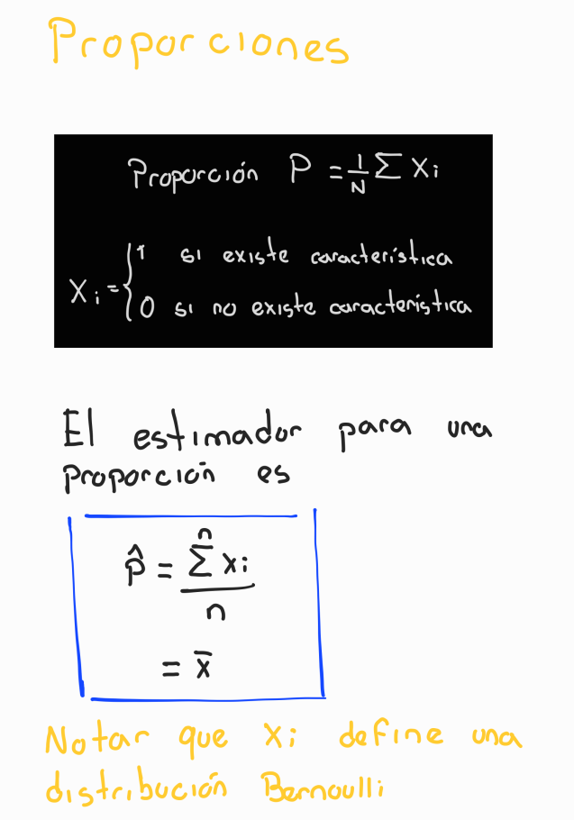

notas

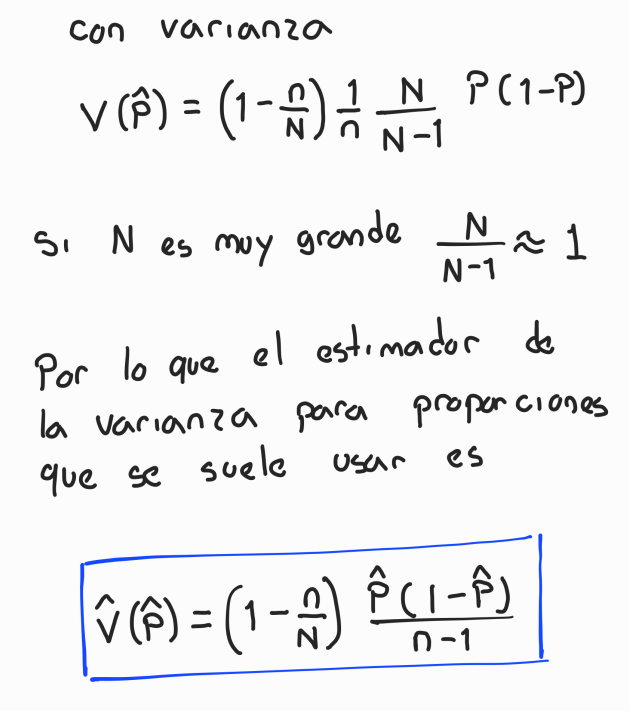

notas

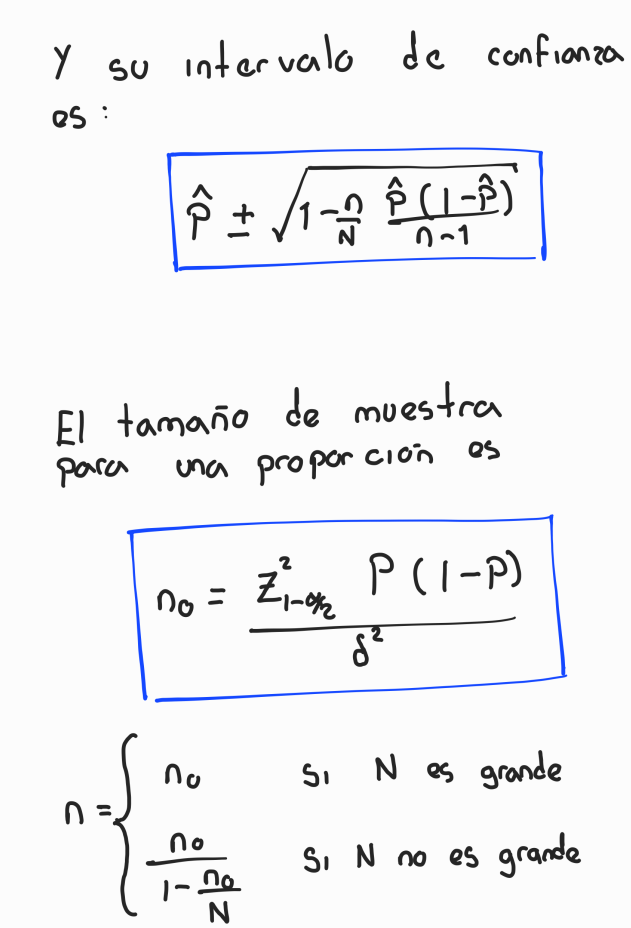

notas

Notar que el tamaño de muestra para una proporción no depende de $N$.

**Distintos valores de P**

En la práctica se utiliza P tal que maximice el valor de la varianza para tener el mayor tamaño de muestra posible.

```r
vector_p <- seq(from = 0, to = 1, by = 0.01)
varianza_p <- vector(length = length(vector_p))


for (i in 1:length(vector_p)) {

  varianza_p[i] <- (vector_p[i])*(1- vector_p[i])

}

tabla_p <- data.frame(p = vector_p, v = varianza_p)
head(tabla_p)
```

```
##      p      v
## 1 0.00 0.0000
## 2 0.01 0.0099
## 3 0.02 0.0196
## 4 0.03 0.0291
## 5 0.04 0.0384
## 6 0.05 0.0475
```

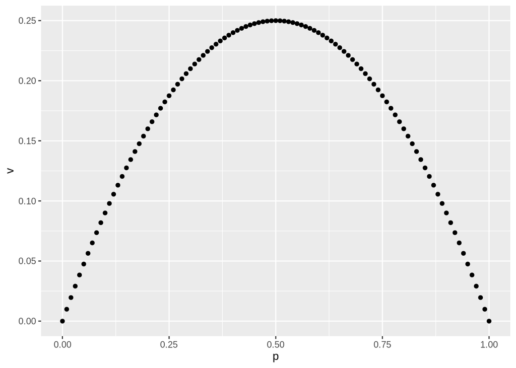

```r
ggplot(data = tabla_p) +
  geom_point(mapping = aes(x = p, y = v))
```

**Tamaño de muestra para proporciones dependiendo de la precisión deseada**

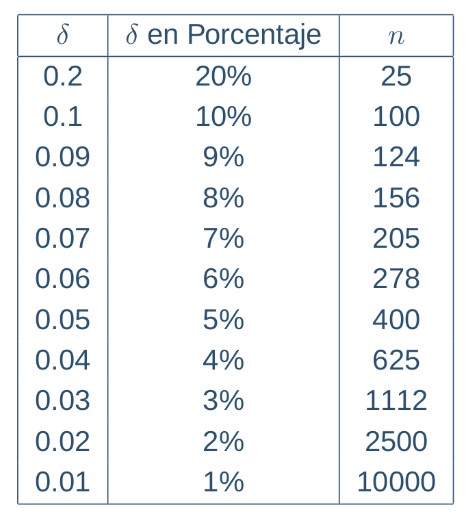

notas

Hagamos un ejemplo Viviendas propias. ¿Qué porcentaje de las viviendas propias tiene la categoría `compra` como forma de adquisción?

```r
datos_interes <- viviendas_09a %>%
  filter(CLAVIVP %in% c("1","2","3","4","9")) %>%
  filter(TENVIV == "1") %>%
  # Crear variable indicadora
  mutate(indicadora = ifelse(FADQUI == "1",1,0))
```

Nuestro universo es

```r
datos_interes %>% summarise(n = n(), num_viviendas = sum(FACTOR))
```

```
## # A tibble: 1 x 2
##       n num_viviendas
##   <int>         <dbl>
## 1 64827       1628389
```

Estos datos coinciden con los tabulados publicados.

La estimación es:

```r
datos_interes %>% summarise(n = n(), p = mean(indicadora), suma = sum(FACTOR))
```

```
## # A tibble: 1 x 3
##       n     p    suma
##   <int> <dbl>   <dbl>
## 1 64827 0.461 1628389
```

¿Por qué la estimación de los totales sí nos coincide con los tabulados ublicados y la estimación de la proporción no? ¿Qué estamos haciendo mal, o qué no estamos considerado?

### Intervalos de Confianza (proporciones)

Construiremos un Intervalo de Confianza para la proporción de la categoría compra.

Asignar valores a variables (Notar que esto se puede automatizar)

```r
N <- 1628389
n <- 64827
```

La varianza estimada está dada por

```r
p <- 0.4611196
var_est <-  ((p*(1-p))/(n-1))*(1 - n/N)
## ee: error estándar
ee <- sqrt(var_est)
ee
```

```
## [1] 0.001918478
```

Definir la confianza

```r
alpha <- 0.10
z <- qnorm(1-alpha/2)
z
```

```
## [1] 1.644854
```

Los límites del intervalo son

```r
limite_inferior <- p - z*ee
limite_superior <- p + z*ee
c(limite_inferior,limite_superior)
```

```
## [1] 0.4579640 0.4642752
```

¿Qué deficiencias identifican al crear este tipo de intervalos para proporciones?

## Ejemplos de Tamaño de muestra

A diferencia de los ejemplos anteriores donde tenemos los datos de la muestra y podemos estimar un valor de $S^{2}$. Para calcular el tamaño de muestra para un nivel de confianza y precisión fijos, necesitamos conocer el valor de $S^{2}$.

- Muestra piloto. Realizar una pequeña muestra con n=50 o n=100 para tener una idea de $S^{2}$.
- Uso de una distribución hipotética. Dependiendo de nuestro objeto de estudio, en algunos casos se puede asumir cierta distribución sobre nuestra variable de interés, por ejemplo, para una variable normal, el ~95% de los datos están a una distancia de de 2 desviaciones estándar de la media; así, se puede considerar un valor de $S = \frac{rango}{4}$

¿Qué falla le encuentran a la recomendación anterior?. Recordemos que estamos en una situación que tenemos nuestro marco muestral, pero no datos.

- Estudios anteriores o datos disponibles en referencias.Este caso será el más usual en la práctica.

**Ejemplo**

De manera ilustrativa, usaremos los datos de uso de [ecobici](https://www.ecobici.cdmx.gob.mx/es/informacion-del-servicio/open-data) del mes de agosto de 2021.

```r
# Limpiar área de trabajo
rm(list = ls())
```

```r
# Cargar librerías
suppressMessages(library(tidyverse))
library(ggplot2)

library(readr)
library(stringr)
library(lubridate)
ecobici <- read_csv("~/Documentos/Acatlan/datos/ecobici/datos_abiertos_ecobici_202108.csv")
glimpse(ecobici)
```

```
## Rows: 354,267
## Columns: 9
## $ Genero_Usuario        <chr> "M", "M", "M", "M", "F", "M", "M", "M", "M…
## $ Edad_Usuario          <dbl> 28, 33, 19, 32, 36, 34, 35, 35, 31, 37, 22…
## $ Bici                  <dbl> 11302, 10571, 12451, 8314, 7993, 10675, 39…
## $ Ciclo_Estacion_Retiro <dbl> 73, 121, 132, 7, 7, 136, 465, 237, 237, 36…
## $ Fecha_Retiro          <chr> "31/07/2021", "31/07/2021", "31/07/2021", …
## $ Hora_Retiro           <time> 23:57:44, 23:54:00, 23:52:58, 23:23:41, 2…
## $ Ciclo_EstacionArribo  <dbl> 62, 143, 122, 7, 7, 68, 461, 24, 24, 366, …
## $ `Fecha Arribo`        <chr> "01/08/2021", "01/08/2021", "01/08/2021", …
## $ Hora_Arribo           <time> 00:00:08, 00:00:59, 00:01:24, 00:01:25, 0…
```

Queremos saber el tiempo promedio de los viajes en ecobici

Hacemos labor de campo y entrevistamos a x personas en las cicloestaciones cuando dejan su bici y preguntamos cuanto duró su viaje.

Primero. ¿Qué sesgos puede haber si sólo entrevisto a una zona?.

Segundo. ¿A cuántas personas debo entrevistar para tener un intervalo de confianza del 95%?.

Crear variable del tiempo de uso

```r
tiempos_ecobici <- ecobici %>%
          rename(Fecha_Arribo = `Fecha Arribo`) %>%
          mutate(Fecha_Retiro = gsub("/","-",Fecha_Retiro),
                 Fecha_Arribo = gsub("/","-",Fecha_Arribo),
                tiempo_inicio = dmy_hms(paste(Fecha_Retiro,Hora_Retiro, sep = " ")),
                tiempo_fin = dmy_hms(paste(Fecha_Arribo,Hora_Arribo, sep = " ")),
                duracion_viaje = tiempo_fin - tiempo_inicio) %>%
                # Filtrar casos donde la bici no se devuelve en ese día
                filter(duracion_viaje < (60*24)) %>%
                filter(duracion_viaje < 90)

glimpse(tiempos_ecobici)
```

```
## Rows: 351,545
## Columns: 12
## $ Genero_Usuario        <chr> "M", "M", "M", "M", "F", "M", "M", "M", "M…
## $ Edad_Usuario          <dbl> 28, 33, 19, 32, 36, 34, 35, 35, 31, 37, 22…
## $ Bici                  <dbl> 11302, 10571, 12451, 8314, 7993, 10675, 39…
## $ Ciclo_Estacion_Retiro <dbl> 73, 121, 132, 7, 7, 136, 465, 237, 237, 36…
## $ Fecha_Retiro          <chr> "31-07-2021", "31-07-2021", "31-07-2021", …
## $ Hora_Retiro           <time> 23:57:44, 23:54:00, 23:52:58, 23:23:41, 2…
## $ Ciclo_EstacionArribo  <dbl> 62, 143, 122, 7, 7, 68, 461, 24, 24, 366, …
## $ Fecha_Arribo          <chr> "01-08-2021", "01-08-2021", "01-08-2021", …
## $ Hora_Arribo           <time> 00:00:08, 00:00:59, 00:01:24, 00:01:25, 0…
## $ tiempo_inicio         <dttm> 2021-07-31 23:57:44, 2021-07-31 23:54:00,…
## $ tiempo_fin            <dttm> 2021-08-01 00:00:08, 2021-08-01 00:00:59,…
## $ duracion_viaje        <drtn> 2.400000 mins, 6.983333 mins, 8.433333 mi…
```

*Con tu tarjeta ECOBICI, toma una bici de cualquier CE y déjala en la más cercana a tu destino. Podrás utilizarla en trayectos ilimitados de 45 minutos cada uno durante el periodo contratado. El horario de servicio es de 05:00 a 00:30 horas de lunes a domingo.*

Los valores reales de nuestra población son

```r
tiempos_ecobici %>% summarise(suma = sum(duracion_viaje), promedio = mean(duracion_viaje), sd = sd(duracion_viaje), min = min(duracion_viaje), max = max(duracion_viaje))
```

```
## # A tibble: 1 x 5
##   suma         promedio         sd min    max
##   <drtn>       <drtn>        <dbl> <drtn> <drtn>
## 1 5540835 mins 15.76138 mins  12.4 2 mins 89.98333 mins
```

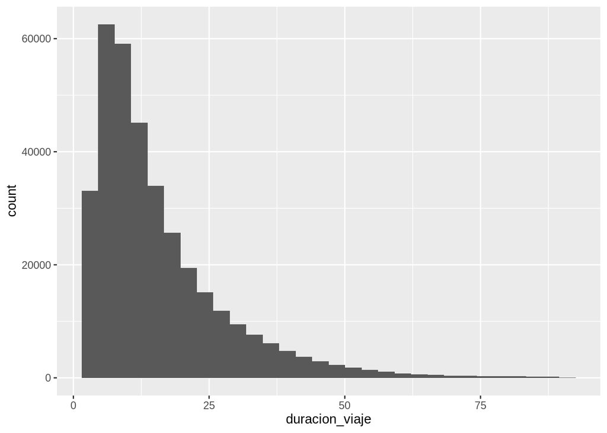

```r
ggplot(tiempos_ecobici) +
  geom_histogram(mapping = aes(x = duracion_viaje))
```

Sin conocimiento previo, saquemos una muestra y calculemos un intervalo de confianza

```r
(N <- dim(tiempos_ecobici)[1])
```

```
## [1] 351545
```

```r
set.seed(12341)
muestra_1 <- tiempos_ecobici %>%
              sample_n(100) %>%
              mutate(factor_exp = (N/100)) %>%
              select(tiempo_inicio, tiempo_fin, duracion_viaje, factor_exp)

glimpse(muestra_1)
```

```
## Rows: 100
## Columns: 4
## $ tiempo_inicio  <dttm> 2021-08-21 17:05:40, 2021-08-10 10:41:27, 2021-0…
## $ tiempo_fin     <dttm> 2021-08-21 17:48:32, 2021-08-10 11:09:40, 2021-0…
## $ duracion_viaje <drtn> 42.866667 mins, 28.216667 mins, 3.883333 mins, 7…
## $ factor_exp     <dbl> 3515.45, 3515.45, 3515.45, 3515.45, 3515.45, 3515…
```

```r
muestra_1 %>% summarise(suma = sum(duracion_viaje), promedio = mean(duracion_viaje), sd = sd(duracion_viaje))
```

[output not shown]

El intervalo al 95% de confianza está dado por

```r
alpha = 0.05
valor = 1 - (alpha/2)
z <- qnorm(p = 0.975, mean = 0, sd = 1)
print(z)
```

```
## [1] 1.959964
```

```r
# Error Estándar
ee <- 16.397 / sqrt(100)

limite_inferior <- 17.01433 - z*ee
limite_superior <- 17.01433 + z*ee
c(limite_inferior,limite_superior)
```

```
## [1] 13.80058 20.22808
```

Ahora calculemos el tamaño de muestra y con ese tamaño de muestra, obtengamos la muestra y su intervalo de confianza

```r
# Fijar parámetros (no confundir la terminología de parámetros de una función con el contexto de parámetros en muestreo)
alpha <- 0.05
z <- qnorm(1 -alpha/2)

delta <- 2 # para nuestro ejemplo de bicis usaremos 2 minutos
S2 <- 12.41002 **2
```

```r
# Función para el tamaño de muestar
N_finita <- function(N,S2,z,delta){

  n0 <- (S2*z**2)/(delta**2)
  return(n0 / (1 + n0/N))
}

N_infinita <- function(S2,z,delta){

  n0 <- (S2*z**2)/(delta**2)
  return(n0)
}
```

El tamaño de mestra que obtenemos es

```r
n <- N_infinita(S2, z, delta)
n
```

```
## [1] 147.9044
```

Por tanto, para la precisión y confianza fijados obtenemos que la muestra debe ser de al menos 148.

Si quisieramos ser más estrictos en la precisión con un valor de 1 min, la muestra aumenta a

```r
N_infinita(S2, z, 1)
```

```
## [1] 591.6177
```

**Ejericio** ¿Qué precisión se requiere para que la muestra sea de tamaño n=100?. Alternativa a solución, usar función buscar objetivo en excel.

**Ejercicio** Considera el factor de ajuste por población finita y calcula nuevamente el intervalo de confianza anterior s considerar el factor de ajuste por población finita $1 - \frac{n}{N}$.

La muestra con el valor de $n$ obtenido es

```r
set.seed(12342)
muestra_2 <- tiempos_ecobici %>%
              sample_n(148) %>%
              mutate(factor_exp = (N/148)) %>%
              select(tiempo_inicio, tiempo_fin, duracion_viaje, factor_exp)

glimpse(muestra_2)
```

```
## Rows: 148
## Columns: 4
## $ tiempo_inicio  <dttm> 2021-08-17 15:34:32, 2021-08-19 21:19:32, 2021-0…
## $ tiempo_fin     <dttm> 2021-08-17 15:43:30, 2021-08-19 21:28:27, 2021-0…
## $ duracion_viaje <drtn> 8.966667 mins, 8.916667 mins, 27.316667 mins, 11…
## $ factor_exp     <dbl> 2375.304, 2375.304, 2375.304, 2375.304, 2375.304,…
```

```r
muestra_2 %>% summarise(suma = sum(duracion_viaje), promedio = mean(duracion_viaje), sd = sd(duracion_viaje))
```

```
## # A tibble: 1 x 3
##   suma          promedio         sd
##   <drtn>        <drtn>        <dbl>
## 1 2643.033 mins 17.85833 mins  14.2
```

El intervalo al 95% de confianza está dado por

```r
alpha = 0.05
valor = 1 - (alpha/2)
z <- qnorm(p = 0.975, mean = 0, sd = 1)
print(z)
```

```
## [1] 1.959964
```

```r
# Error Estándar
ee <- 14.21652   / sqrt(148)
ee
```

```
## [1] 1.168591
```

```r
limite_inferior <- 17.85833 - z*ee
limite_superior <- 17.85833 + z*ee
c(limite_inferior,limite_superior)
```

```
## [1] 15.56793 20.14873
```

Como podemos ver, aumentar el tamaño de muestra hizo que nuestro intervalo disminuyera su longitud.

Corroboremos los resultados obtenidos usando una librería de R diseñada para muestreo

Cargamos librería

```r
suppressMessages(library(survey))
```

Definir diseño de MAS

```r
disenio_mas <-svydesign(id=~1, weights=~1,data=muestra_2)
```

Estimación

```r
promedio <-  svymean(~duracion_viaje,disenio_mas)
promedio
```

```
##                  mean     SE
## duracion_viaje 17.858 1.1686
```

Coeficiente de variación

```r
cv(promedio)
```

```
##                duracion_viaje
## duracion_viaje     0.06543673
```

Intervalos de Confianza

```r
confint(promedio,level=0.95)
```

```
##                   2.5 %   97.5 %
## duracion_viaje 15.56794 20.14873
```

**Tamaño de muestra para proporciones**

Deseamos hacer una estimación para conocer la propoción de usuarios que son mujeres, con un intervalo de confianza del 95% y una precisión de 5 puntos porcentuales.

**Importante**. Notar que los tamaños de muestra están en función de la precisión deseada ($\delta$) y la escala de ésta varia conforme al problema.

Recordemos que la fórmula para el tamaño de muestra de una proporción es

$$\frac{Z^{2} \cdot P(1-P)}{\delta^{2}}$$

Considerando un intervalo con una confianza de 95, a veces se llega a simplificar la expresión anterior a

$$\frac{2^{2} \cdot 0.5(1-0.5)}{\delta^{2}} = \frac{1}{\delta^{2}}$$

Se redondea el cuantil $z$ de 1.96 a 2 y se toma $P=0.5$ para maximizar la varianza y considerar el mayor número de muestra para los distintos valores de $P$.

```r
set.seed(12343)
muestra_p <- tiempos_ecobici %>%
              filter(!is.na(Genero_Usuario)) %>%
              sample_n(400) %>%
              mutate(indicadora = ifelse(Genero_Usuario == "F",1,0)) %>%
              select(tiempo_inicio, tiempo_fin, duracion_viaje, Genero_Usuario, indicadora)

glimpse(muestra_p)
```

```
## Rows: 400
## Columns: 5
## $ tiempo_inicio  <dttm> 2021-08-24 10:56:59, 2021-08-13 17:00:31, 2021-0…
## $ tiempo_fin     <dttm> 2021-08-24 11:16:56, 2021-08-13 17:08:02, 2021-0…
## $ duracion_viaje <drtn> 19.950000 mins, 7.516667 mins, 11.400000 mins, 2…
## $ Genero_Usuario <chr> "M", "M", "M", "M", "M", "F", "M", "M", "M", "M",…
## $ indicadora     <dbl> 0, 0, 0, 0, 0, 1, 0, 0, 0, 0, 0, 0, 0, 0, 0, 0, 0…
```

```r
muestra_p %>% summarise(p = mean(indicadora, na.rm = TRUE), sd = sd(indicadora, na.rm = TRUE))
```

```
## # A tibble: 1 x 2
##       p    sd
##   <dbl> <dbl>
## 1 0.285 0.452
```

El intervalo al 95% de confianza está dado por

```r
alpha = 0.05
valor = 1 - (alpha/2)
z <- qnorm(p = 0.975, mean = 0, sd = 1)
print(z)
```

```
## [1] 1.959964
```

Utilizando la fórmula vista arriba tenemos que el error estándar de nuestro estimador es

$$\hat{V}(\hat{p}) = \frac{\hat{p}(1-\hat{p})}{n-1}$$

```r
# Error Estándar
p_est <- 0.285
ee <- sqrt(p_est * (1 - p_est))/ sqrt(400-1)
ee
```

```
## [1] 0.02259899
```

```r
limite_inferior <- 0.285 - z*ee
limite_superior <- 0.285 + z*ee
c(limite_inferior,limite_superior)
```

```
## [1] 0.2407068 0.3292932
```

Corroboremos los resultados obtenidos usando una librería de R diseñada para muestreo

Definir diseño de MAS

```r
disenio_mas <-svydesign(id=~1, weights=~1,data=muestra_p)
```

Estimación

```r
proporcion <-  svymean(~indicadora,disenio_mas)
proporcion
```

```
##             mean     SE
## indicadora 0.285 0.0226
```

Coeficiente de variación

```r
cv(proporcion)
```

```
##            indicadora
## indicadora  0.0792947
```

Intervalos de Confianza

```r
confint(proporcion,level=0.95)
```

```
##                2.5 %    97.5 %
## indicadora 0.2407068 0.3292932
```

Sólo para validar, veamos los valores poblacionales

```r
tiempos_ecobici %>%
              filter(!is.na(Genero_Usuario)) %>%
              mutate(indicadora = ifelse(Genero_Usuario == "F",1,0)) %>%
              summarise( p = mean(indicadora), sd = sd(indicadora))
```

```
## # A tibble: 1 x 2
##       p    sd
##   <dbl> <dbl>
## 1 0.271 0.444
```

Para la muestra elegida, el intervalo sí cntiene el parámetro poblacional.

**preguntas**

- ¿Qué pasaría si para una proproción fijara una presición $\delta$ de 1?
- piensen un caso donde hacer muestreo aleatorio simple para proporciones pueda dar resultados no esperados en las estimaciones.